# Notebook 04 – Solutions

## 0.1 Getting Started

Before running this notebook, select “Session > Restart R and Clear Output” in the menu above to start a new R session. This will clear any old data sets and give us a blank slate to start with.

After starting a new session, run the following code chunk to load the libraries and data that we will be working with today.

I have set the options `include=FALSE` and `message=FALSE` to avoid cluttering the solutions with all the output from this code.

# 1 Practice

We will work with the largest cities data sets:

```r
cities <- read_csv("../data/largest_cities.csv")
cities
```

| name | country | city_definition | population | city_pop | city_area | metro_pop | metro_area | urban_pop | urban_area | wiki | country_code2 | country_code3 | country_name_official | continent | lon | lat | koppen_code | koppen_main | city | num | cost_of_living | cost_rent | cost_groceries | cost_restaurant | local_pp |
| --- | --- | --- | --- | --- | --- | --- | --- | --- | --- | --- | --- | --- | --- | --- | --- | --- | --- | --- | --- | --- | --- | --- | --- | --- | --- |
| Tokyo | Japan | Metropolis prefecture | 37.400 | 13.515 | 2191.00 | 37.274 | 13452.0 | 38.505 | 8223 | Tokyo | JP | JPN | Japan | Asia | 139.692222 | 35.689722 | Cfa | Temperate | Tokyo, Japan | 18 | 86.87 | 38.00 | 83.42 | 56.70 | 89.70 |
| Delhi | India | National capital territory | 28.514 | 16.753 | 1484.00 | 29.000 | 3483.0 | 28.125 | 2240 | Delhi | IN | IND | India, Republic of | Asia | 77.230000 | 28.610000 | BSh | Dry | Delhi, India | 405 | 28.18 | 8.18 | 26.15 | 24.76 | 54.69 |
| Shanghai | China | Municipality | 25.582 | 24.183 | 6341.00 | NA | NA | 22.125 | 4015 | Shanghai | CN | CHN | China, People's Republic of | Asia | 121.474722 | 31.228611 | Cfa | Temperate | Shanghai, China | 235 | 50.07 | 35.67 | 52.50 | 36.48 | 54.40 |
| São Paulo | Brazil | Municipality | 21.650 | 12.252 | 1521.00 | 21.735 | 7947.0 | 20.935 | 3043 | Sao_Paulo | BR | BRA | Brazil, Federative Republic of | South America | -46.633333 | -23.550000 | Cfb | Temperate | Sao Paulo, Brazil | 257 | 45.52 | 16.28 | 33.29 | 39.70 | 31.97 |
| Mexico City | Mexico | City-state | 21.581 | 8.919 | 1485.00 | 20.893 | 7854.0 | 20.395 | 237 | Mexico_City | MX | MEX | Mexico, United Mexican States | North America | -99.133333 | 19.433333 | Cwb | Temperate | Mexico City, Mexico | 317 | 38.55 | 20.43 | 33.75 | 33.11 | 42.91 |
| Cairo | Egypt | Urban governorate | 20.076 | 9.500 | 3085.00 | NA | NA | 16.925 | 1917 | Cairo | EG | EGY | Egypt, Arab Republic of | Africa | 31.228889 | 30.058056 | BWh | Dry | Cairo, Egypt | 393 | 30.94 | 6.48 | 26.41 | 25.43 | 24.53 |
| Mumbai | India | Municipality | 19.980 | 12.478 | 603.00 | 24.400 | 4355.0 | 23.645 | 881 | Mumbai | IN | IND | India, Republic of | Asia | 72.825833 | 18.975000 | Am | Tropical | Mumbai, India | 399 | 28.84 | 21.02 | 26.86 | 26.61 | 41.68 |
| Beijing | China | Municipality | 19.618 | 21.707 | 16411.00 | NA | NA | 19.430 | 4144 | Beijing | CN | CHN | China, People's Republic of | Asia | 116.383333 | 39.916667 | Cwa | Temperate | Beijing, China | 261 | 44.89 | 34.97 | 43.08 | 35.85 | 60.72 |
| Dhaka | Bangladesh | Capital city | 19.578 | 14.399 | 338.00 | 14.543 | NA | 18.595 | 453 | Dhaka | BD | BGD | Bangladesh, People's Republic of | Asia | 90.388889 | 23.763889 | Aw | Tropical | Dhaka, Bangladesh | 370 | 34.52 | 5.69 | 31.58 | 20.02 | 33.45 |
| Osaka | Japan | Designated city | 19.281 | 2.725 | 225.00 | 19.303 | 13228.0 | 17.150 | 3004 | Osaka | JP | JPN | Japan | Asia | 135.502222 | 34.693889 | Cfa | Temperate | Osaka, Japan | 33 | 79.54 | 22.63 | 77.66 | 45.48 | 85.82 |

[output cut: 71 more lines]

We will now also work with the entire U.S. cities data set:

```r
us <- read_csv("../data/us_city_population.csv")
us
```

| city | state | year | population | lon | lat |
| --- | --- | --- | --- | --- | --- |
| Anchorage, AK | AK | 1790 | 0.000 | -149.27435 | 61.17755 |
| Birmingham, AL | AL | 1790 | 0.000 | -86.79905 | 33.52744 |
| Huntsville, AL | AL | 1790 | 0.000 | -86.53900 | 34.78427 |
| Mobile, AL | AL | 1790 | 0.000 | -88.10023 | 30.66843 |
| Montgomery, AL | AL | 1790 | 0.000 | -86.26859 | 32.34625 |
| Little Rock, AR | AR | 1790 | 0.000 | -92.35856 | 34.72543 |
| Chandler, AZ | AZ | 1790 | 0.000 | -111.85494 | 33.28287 |
| Gilbert, AZ | AZ | 1790 | 0.000 | -111.74219 | 33.31021 |
| Glendale, AZ | AZ | 1790 | 0.000 | -112.18990 | 33.53311 |
| Mesa, AZ | AZ | 1790 | 0.000 | -111.71738 | 33.40193 |

[output cut: 6890 more lines]

Please refer to the previous notebooks for more information about these data sets and how these data sets are organized.

## 1.1 Selecting rows and columns

Take the `cities` data set and select only the first 5 rows. (Note: for this and other questions in the notebook, just write the code to produce the required data. There is no need to save the results as a variable unless specifically asked to)

```r
cities |>
  slice(1:5)
```

| name | country | city_definition | population | city_pop | city_area | metro_pop | metro_area | urban_pop | urban_area | wiki | country_code2 | country_code3 | country_name_official | continent | lon | lat | koppen_code | koppen_main | city | num | cost_of_living | cost_rent | cost_groceries | cost_restaurant | local_pp |
| --- | --- | --- | --- | --- | --- | --- | --- | --- | --- | --- | --- | --- | --- | --- | --- | --- | --- | --- | --- | --- | --- | --- | --- | --- | --- |
| Tokyo | Japan | Metropolis prefecture | 37.400 | 13.515 | 2191 | 37.274 | 13452 | 38.505 | 8223 | Tokyo | JP | JPN | Japan | Asia | 139.69222 | 35.68972 | Cfa | Temperate | Tokyo, Japan | 18 | 86.87 | 38.00 | 83.42 | 56.70 | 89.70 |
| Delhi | India | National capital territory | 28.514 | 16.753 | 1484 | 29.000 | 3483 | 28.125 | 2240 | Delhi | IN | IND | India, Republic of | Asia | 77.23000 | 28.61000 | BSh | Dry | Delhi, India | 405 | 28.18 | 8.18 | 26.15 | 24.76 | 54.69 |
| Shanghai | China | Municipality | 25.582 | 24.183 | 6341 | NA | NA | 22.125 | 4015 | Shanghai | CN | CHN | China, People's Republic of | Asia | 121.47472 | 31.22861 | Cfa | Temperate | Shanghai, China | 235 | 50.07 | 35.67 | 52.50 | 36.48 | 54.40 |
| São Paulo | Brazil | Municipality | 21.650 | 12.252 | 1521 | 21.735 | 7947 | 20.935 | 3043 | Sao_Paulo | BR | BRA | Brazil, Federative Republic of | South America | -46.63333 | -23.55000 | Cfb | Temperate | Sao Paulo, Brazil | 257 | 45.52 | 16.28 | 33.29 | 39.70 | 31.97 |
| Mexico City | Mexico | City-state | 21.581 | 8.919 | 1485 | 20.893 | 7854 | 20.395 | 237 | Mexico_City | MX | MEX | Mexico, United Mexican States | North America | -99.13333 | 19.43333 | Cwb | Temperate | Mexico City, Mexico | 317 | 38.55 | 20.43 | 33.75 | 33.11 | 42.91 |

Now, filter the data set to include only those cities with a population (`population`) over 10 million people.

```r
cities |>
  filter(population > 10)
```

| name | country | city_definition | population | city_pop | city_area | metro_pop | metro_area | urban_pop | urban_area | wiki | country_code2 | country_code3 | country_name_official | continent | lon | lat | koppen_code | koppen_main | city | num | cost_of_living | cost_rent | cost_groceries | cost_restaurant | local_pp |
| --- | --- | --- | --- | --- | --- | --- | --- | --- | --- | --- | --- | --- | --- | --- | --- | --- | --- | --- | --- | --- | --- | --- | --- | --- | --- |
| Tokyo | Japan | Metropolis prefecture | 37.400 | 13.515 | 2191 | 37.274 | 13452 | 38.505 | 8223 | Tokyo | JP | JPN | Japan | Asia | 139.692222 | 35.689722 | Cfa | Temperate | Tokyo, Japan | 18 | 86.87 | 38.00 | 83.42 | 56.70 | 89.70 |
| Delhi | India | National capital territory | 28.514 | 16.753 | 1484 | 29.000 | 3483 | 28.125 | 2240 | Delhi | IN | IND | India, Republic of | Asia | 77.230000 | 28.610000 | BSh | Dry | Delhi, India | 405 | 28.18 | 8.18 | 26.15 | 24.76 | 54.69 |
| Shanghai | China | Municipality | 25.582 | 24.183 | 6341 | NA | NA | 22.125 | 4015 | Shanghai | CN | CHN | China, People's Republic of | Asia | 121.474722 | 31.228611 | Cfa | Temperate | Shanghai, China | 235 | 50.07 | 35.67 | 52.50 | 36.48 | 54.40 |
| São Paulo | Brazil | Municipality | 21.650 | 12.252 | 1521 | 21.735 | 7947 | 20.935 | 3043 | Sao_Paulo | BR | BRA | Brazil, Federative Republic of | South America | -46.633333 | -23.550000 | Cfb | Temperate | Sao Paulo, Brazil | 257 | 45.52 | 16.28 | 33.29 | 39.70 | 31.97 |
| Mexico City | Mexico | City-state | 21.581 | 8.919 | 1485 | 20.893 | 7854 | 20.395 | 237 | Mexico_City | MX | MEX | Mexico, United Mexican States | North America | -99.133333 | 19.433333 | Cwb | Temperate | Mexico City, Mexico | 317 | 38.55 | 20.43 | 33.75 | 33.11 | 42.91 |
| Cairo | Egypt | Urban governorate | 20.076 | 9.500 | 3085 | NA | NA | 16.925 | 1917 | Cairo | EG | EGY | Egypt, Arab Republic of | Africa | 31.228889 | 30.058056 | BWh | Dry | Cairo, Egypt | 393 | 30.94 | 6.48 | 26.41 | 25.43 | 24.53 |
| Mumbai | India | Municipality | 19.980 | 12.478 | 603 | 24.400 | 4355 | 23.645 | 881 | Mumbai | IN | IND | India, Republic of | Asia | 72.825833 | 18.975000 | Am | Tropical | Mumbai, India | 399 | 28.84 | 21.02 | 26.86 | 26.61 | 41.68 |
| Beijing | China | Municipality | 19.618 | 21.707 | 16411 | NA | NA | 19.430 | 4144 | Beijing | CN | CHN | China, People's Republic of | Asia | 116.383333 | 39.916667 | Cwa | Temperate | Beijing, China | 261 | 44.89 | 34.97 | 43.08 | 35.85 | 60.72 |
| Dhaka | Bangladesh | Capital city | 19.578 | 14.399 | 338 | 14.543 | NA | 18.595 | 453 | Dhaka | BD | BGD | Bangladesh, People's Republic of | Asia | 90.388889 | 23.763889 | Aw | Tropical | Dhaka, Bangladesh | 370 | 34.52 | 5.69 | 31.58 | 20.02 | 33.45 |
| Osaka | Japan | Designated city | 19.281 | 2.725 | 225 | 19.303 | 13228 | 17.150 | 3004 | Osaka | JP | JPN | Japan | Asia | 135.502222 | 34.693889 | Cfa | Temperate | Osaka, Japan | 33 | 79.54 | 22.63 | 77.66 | 45.48 | 85.82 |

[output cut: 23 more lines]

How many cities have a population over 10 million people? **Answer**: 33

In the code block below, extract the cities that have between 7 and 10 million people.

```r
cities |>
  filter(between(population, 7, 10))
```

| name | country | city_definition | population | city_pop | city_area | metro_pop | metro_area | urban_pop | urban_area | wiki | country_code2 | country_code3 | country_name_official | continent | lon | lat | koppen_code | koppen_main | city | num | cost_of_living | cost_rent | cost_groceries | cost_restaurant | local_pp |
| --- | --- | --- | --- | --- | --- | --- | --- | --- | --- | --- | --- | --- | --- | --- | --- | --- | --- | --- | --- | --- | --- | --- | --- | --- | --- |
| Seoul | South Korea | Special city | 9.963 | 9.806 | 605 | 25.514 | 11704 | 24.315 | 2745 | Seoul | KR | KOR | Korea, Republic of | Asia | 126.96667 | 37.566667 | Dwa | Continental | Seoul, South Korea | 23 | 85.50 | 30.45 | 103.69 | 45.88 | 76.81 |
| Nagoya | Japan | Designated city | 9.507 | 2.320 | 326 | 9.363 | 7271 | 10.240 | 3704 | Nagoya | JP | JPN | Japan | Asia | 136.90000 | 35.183333 | Cfa | Temperate | NA | NA | NA | NA | NA | NA | NA |
| Hyderabad | India | Municipality | 9.482 | 6.993 | 650 | NA | NA | 9.580 | 123 | Hyderabad | IN | IND | India, Republic of | Asia | 78.48333 | 17.366667 | BSh | Dry | Hyderabad, India | 419 | 25.32 | 6.41 | 26.25 | 16.68 | 57.90 |
| London | United Kingdom | Capital city | 9.046 | 8.825 | 1572 | 14.373 | NA | 10.840 | 1738 | London | GB | GBR | United Kingdom of Great Britain & Northern Ireland | Europe | -0.12750 | 51.507222 | Cfb | Temperate | London, United Kingdom | 28 | 81.30 | 70.01 | 57.31 | 89.04 | 78.16 |
| Tehran | Iran | Capital city | 8.896 | 9.033 | 751 | NA | NA | 14.630 | 1943 | Tehran | IR | IRN | Iran, Islamic Republic of | Asia | 51.38889 | 35.689167 | BSk | Dry | Tehran, Iran | 285 | 41.67 | 19.60 | 36.44 | 26.43 | 18.83 |
| Chicago | United States | City | 8.864 | 2.706 | 589 | 9.499 | 1864 | 9.275 | 6856 | Chicago | US | USA | United States of America | North America | -87.62778 | 41.881944 | Dfa | Continental | Chicago, IL, United States | 32 | 80.18 | 58.64 | 76.47 | 76.67 | 113.52 |
| Chengdu | China | City (sub-provincial) | 8.813 | 16.045 | 14378 | NA | NA | 12.160 | 1813 | Chengdu | CN | CHN | China, People's Republic of | Asia | 104.06611 | 30.656944 | Cwa | Temperate | Chengdu, China | 300 | 39.81 | 10.29 | 43.80 | 24.70 | 60.50 |
| Nanjing | China | City (sub-provincial) | 8.245 | 7.260 | 6582 | NA | NA | 6.125 | 1489 | Nanjing | CN | CHN | China, People's Republic of | Asia | 118.76361 | 32.061389 | Cfa | Temperate | Nanjing, China | 293 | 40.86 | 15.58 | 37.87 | 28.82 | 58.77 |
| Wuhan | China | City (sub-provincial) | 8.176 | 10.893 | 8494 | NA | NA | 8.470 | 1619 | Wuhan | CN | CHN | China, People's Republic of | Asia | 114.28806 | 30.587222 | Cfa | Temperate | NA | NA | NA | NA | NA | NA | NA |
| Ho Chi Minh City | Vietnam | Municipality | 8.145 | 7.431 | 2061 | NA | NA | 10.955 | 1645 | Ho_Chi_Minh_City | VN | VNM | Vietnam, Socialist Republic of | Asia | 106.65000 | 10.800000 | Aw | Tropical | Ho Chi Minh City, Vietnam | 321 | 38.20 | 16.74 | 36.30 | 20.71 | 26.64 |

[output cut: 8 more lines]

How many cities have a population between 7 and 10 million people? **Answer**: 18

In the code block below, extract the cities in Asia that have between 7 and 10 million people

```r
cities |>
  filter(between(population, 7, 10)) |>
  filter(continent %in% c("Asia"))
```

| name | country | city_definition | population | city_pop | city_area | metro_pop | metro_area | urban_pop | urban_area | wiki | country_code2 | country_code3 | country_name_official | continent | lon | lat | koppen_code | koppen_main | city | num | cost_of_living | cost_rent | cost_groceries | cost_restaurant | local_pp |
| --- | --- | --- | --- | --- | --- | --- | --- | --- | --- | --- | --- | --- | --- | --- | --- | --- | --- | --- | --- | --- | --- | --- | --- | --- | --- |
| Seoul | South Korea | Special city | 9.963 | 9.806 | 605 | 25.514 | 11704 | 24.315 | 2745 | Seoul | KR | KOR | Korea, Republic of | Asia | 126.96667 | 37.566667 | Dwa | Continental | Seoul, South Korea | 23 | 85.50 | 30.45 | 103.69 | 45.88 | 76.81 |
| Nagoya | Japan | Designated city | 9.507 | 2.320 | 326 | 9.363 | 7271 | 10.240 | 3704 | Nagoya | JP | JPN | Japan | Asia | 136.90000 | 35.183333 | Cfa | Temperate | NA | NA | NA | NA | NA | NA | NA |
| Hyderabad | India | Municipality | 9.482 | 6.993 | 650 | NA | NA | 9.580 | 123 | Hyderabad | IN | IND | India, Republic of | Asia | 78.48333 | 17.366667 | BSh | Dry | Hyderabad, India | 419 | 25.32 | 6.41 | 26.25 | 16.68 | 57.90 |
| Tehran | Iran | Capital city | 8.896 | 9.033 | 751 | NA | NA | 14.630 | 1943 | Tehran | IR | IRN | Iran, Islamic Republic of | Asia | 51.38889 | 35.689167 | BSk | Dry | Tehran, Iran | 285 | 41.67 | 19.60 | 36.44 | 26.43 | 18.83 |
| Chengdu | China | City (sub-provincial) | 8.813 | 16.045 | 14378 | NA | NA | 12.160 | 1813 | Chengdu | CN | CHN | China, People's Republic of | Asia | 104.06611 | 30.656944 | Cwa | Temperate | Chengdu, China | 300 | 39.81 | 10.29 | 43.80 | 24.70 | 60.50 |
| Nanjing | China | City (sub-provincial) | 8.245 | 7.260 | 6582 | NA | NA | 6.125 | 1489 | Nanjing | CN | CHN | China, People's Republic of | Asia | 118.76361 | 32.061389 | Cfa | Temperate | Nanjing, China | 293 | 40.86 | 15.58 | 37.87 | 28.82 | 58.77 |
| Wuhan | China | City (sub-provincial) | 8.176 | 10.893 | 8494 | NA | NA | 8.470 | 1619 | Wuhan | CN | CHN | China, People's Republic of | Asia | 114.28806 | 30.587222 | Cfa | Temperate | NA | NA | NA | NA | NA | NA | NA |
| Ho Chi Minh City | Vietnam | Municipality | 8.145 | 7.431 | 2061 | NA | NA | 10.955 | 1645 | Ho_Chi_Minh_City | VN | VNM | Vietnam, Socialist Republic of | Asia | 106.65000 | 10.800000 | Aw | Tropical | Ho Chi Minh City, Vietnam | 321 | 38.20 | 16.74 | 36.30 | 20.71 | 26.64 |
| Ahmedabad | India | Municipality | 7.681 | 5.571 | 464 | 6.300 | NA | 7.715 | 350 | Ahmedabad | IN | IND | India, Republic of | Asia | 72.58333 | 23.033333 | BSh | Dry | Ahmedabad, India | 416 | 25.58 | 7.22 | 25.90 | 17.72 | 38.52 |
| Kuala Lumpur | Malaysia | City | 7.564 | 1.768 | 243 | 7.200 | 2793 | 7.860 | 2163 | Kuala_Lumpur | MY | MYS | Malaysia | Asia | 101.69528 | 3.147778 | Af | Tropical | Kuala Lumpur, Malaysia | 280 | 42.47 | 15.18 | 40.77 | 27.32 | 67.27 |

[output cut: 5 more lines]

How many Asian cities have a population between 7 and 10 million people? **Answer**: 15

## 1.2 Filtering plot

Take the data set `us`. Select only the year 1800 and remove rows that have a population of zero.

```r
us |>
  filter(year == 1800) |>
  filter(population > 0)
```

| city | state | year | population | lon | lat |
| --- | --- | --- | --- | --- | --- |
| Hartford, CT | CT | 1800 | 3.523 | -72.68334 | 41.76605 |
| New Haven, CT | CT | 1800 | 4.049 | -72.92495 | 41.31081 |
| Washington, DC | DC | 1800 | 3.210 | -77.01709 | 38.90415 |
| Savannah, GA | GA | 1800 | 5.146 | -81.15356 | 32.00251 |
| Lexington, KY | KY | 1800 | 1.800 | -84.45844 | 38.04016 |
| Louisville, KY | KY | 1800 | 0.400 | -85.66671 | 38.17808 |
| Boston, MA | MA | 1800 | 24.937 | -71.02017 | 42.33196 |
| New Bedford, MA | MA | 1800 | 4.361 | -70.93791 | 41.66130 |
| Springfield, MA | MA | 1800 | 2.300 | -72.53998 | 42.11545 |
| Worcester, MA | MA | 1800 | 2.400 | -71.80778 | 42.26948 |

[output cut: 12 more lines]

How many cities have a non-zero population given for the year 1800? **Answer**: 22

Now, starting with the data set you produced in the last chunk of code, produce a plot with city on the x-axis and and population on the y-axis using the `geom_col` layer:

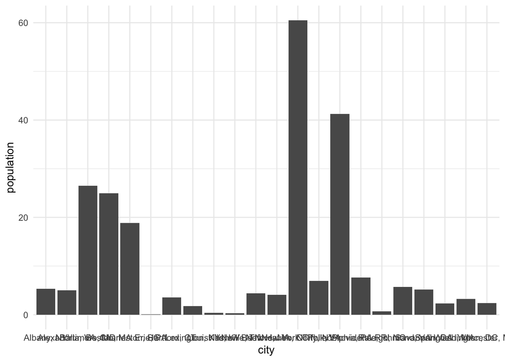

```r
us |>
  filter(year == 1800) |>
  filter(population > 0) |>
  ggplot(aes(city, population)) +
  geom_col()
```

You will notice that the labels are too difficult to read because they run into one another. Modify this plot in the code block below by flipping the x and y aesthetics:

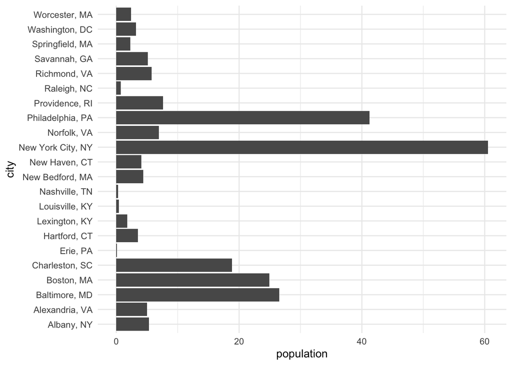

```r
us |>
  filter(year == 1800) |>
  filter(population > 0) |>
  ggplot(aes(population, city)) +
  geom_col()
```

How easy do you find this plot to read? What improvements might you want to make to it? (Don’t worry about what you can do right now; think about what would make it easier to interpret). **Answer**: I find it relatively easy to read, though it would be good to re-order the data in a more meaningful way, such as from the largest to the smallest city.

## 1.3 Arranging rows

In the code below, extract the five European cities from `cities` that have the largest population. (Note: this will take three different verbs).

```r
cities |>
  filter(continent == "Europe") |>
  arrange(desc(population)) |>
  slice(1:5)
```

| name | country | city_definition | population | city_pop | city_area | metro_pop | metro_area | urban_pop | urban_area | wiki | country_code2 | country_code3 | country_name_official | continent | lon | lat | koppen_code | koppen_main | city | num | cost_of_living | cost_rent | cost_groceries | cost_restaurant | local_pp |
| --- | --- | --- | --- | --- | --- | --- | --- | --- | --- | --- | --- | --- | --- | --- | --- | --- | --- | --- | --- | --- | --- | --- | --- | --- | --- |
| Istanbul | Turkey | Metropolitan municipality | 14.751 | 15.029 | 5196 | NA | NA | 13.860 | 136 | Istanbul | TR | TUR | Turkey, Republic of | Europe | 28.955000 | 41.01361 | Csa | Temperate | Istanbul, Turkey | 325 | 38.01 | 9.84 | 32.30 | 28.30 | 38.23 |
| Moscow | Russia | Federal city | 12.410 | 13.200 | 2511 | NA | NA | 16.555 | 5698 | Moscow | RU | RUS | Russian Federation | Europe | 37.617222 | 55.75583 | Dfb | Continental | Moscow, Russia | 251 | 47.65 | 31.39 | 35.67 | 48.82 | 52.28 |
| Paris | France | Commune | 10.901 | 2.148 | 105 | 12.245 | NA | 10.960 | 2845 | Paris | FR | FRA | France, French Republic | Europe | 2.352222 | 48.85667 | Cfb | Temperate | Paris, France | 24 | 85.16 | 46.98 | 78.98 | 81.35 | 71.17 |
| London | United Kingdom | Capital city | 9.046 | 8.825 | 1572 | 14.373 | NA | 10.840 | 1738 | London | GB | GBR | United Kingdom of Great Britain & Northern Ireland | Europe | -0.127500 | 51.50722 | Cfb | Temperate | London, United Kingdom | 28 | 81.30 | 70.01 | 57.31 | 89.04 | 78.16 |
| Madrid | Spain | Municipality | 6.497 | 3.266 | 606 | 6.642 | NA | 6.345 | 136 | Madrid | ES | ESP | Spain, Kingdom of | Europe | -3.716667 | 40.38333 | BSk | Dry | Madrid, Spain | 206 | 58.25 | 32.53 | 45.53 | 60.23 | 73.65 |

Which European city in our data set has the largest population? **Answer**: Istanbul (though, technically much of the city is actually in Asia).

## 1.4 Selecting columns

Take the `cities` data set and filter only those cities in Africa and Europe. Use the select function to see just the city name and the variable `koppen_code`.

```r
cities |>
  filter(continent %in% c("Africa", "Europe")) |>
  select(name, koppen_code)
```

| name | koppen_code |
| --- | --- |
| Cairo | BWh |
| Istanbul | Csa |
| Lagos | Aw |
| Kinshasa | Aw |
| Moscow | Dfb |
| Paris | Cfb |
| London | Cfb |
| Luanda | BSh |
| Madrid | BSk |
| Dar es Salaam | Aw |

[output cut: 5 more lines]

## 1.5 Layering graphics

In the code below, create a data set called `cities_large_metro` by extracting the rows of `cities` that have a metro region larger than the U.N. estimate of the city’s population.

```r
cities_large_metro <- cities |>
  filter(population < metro_pop)
```

Now, draw a scatter plot with longitude on the x-axis and latitude on the y-axis. Show all of the rows in the data set using a light grey color. Then, add points layer and a text layer (with the city names as labels) for the rows in `cities_large_metro`. Pick a bold color for the points and labels.

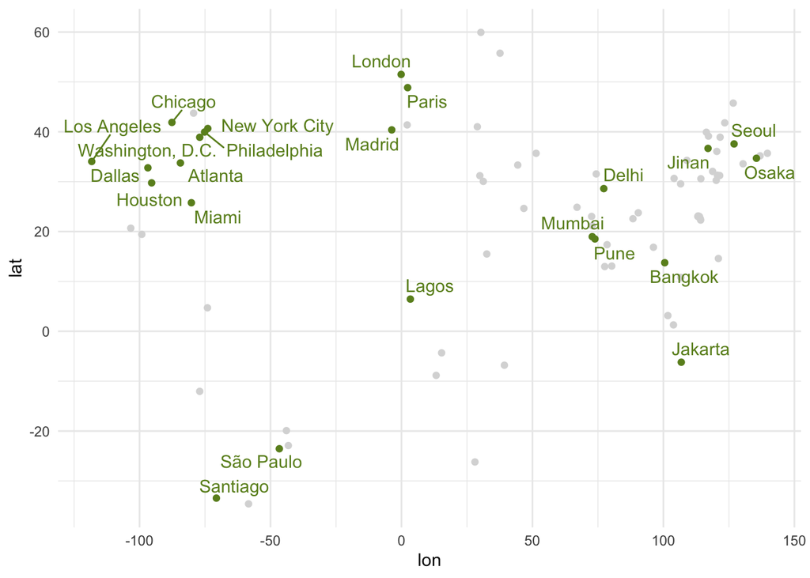

```r
cities |>
  ggplot(aes(lon, lat)) +
  geom_point(color = "grey85") +
  geom_point(color = "olivedrab", data = cities_large_metro) +
  geom_text_repel(aes(label = name), color = "olivedrab", data = cities_large_metro)
```

Do you see any particular patterns about which cities have metropolitan regions that are larger than the city’s official U.N.-listed population? (Note: There is at least one thing that becomes apparent, but you will probably not find something that explains all of the data). **Answer**: While there are cities in all of the major continents, there is a particular concentration of cities with large metro areas in the United States.

## 1.6 A better bar plot

Let’s now try to build a better bar plot. In the next code chunk, take the `us` dataset, filter to just the year 1800 and cities with a non-zero population, and arrange the cities by their population:

```r
us |>
  filter(year == 1800) |>
  filter(population > 0) |>
  arrange(population)
```

| city | state | year | population | lon | lat |
| --- | --- | --- | --- | --- | --- |
| Erie, PA | PA | 1800 | 0.100 | -80.07350 | 42.11659 |
| Nashville, TN | TN | 1800 | 0.300 | -86.78500 | 36.17180 |
| Louisville, KY | KY | 1800 | 0.400 | -85.66671 | 38.17808 |
| Raleigh, NC | NC | 1800 | 0.700 | -78.64144 | 35.83020 |
| Lexington, KY | KY | 1800 | 1.800 | -84.45844 | 38.04016 |
| Springfield, MA | MA | 1800 | 2.300 | -72.53998 | 42.11545 |
| Worcester, MA | MA | 1800 | 2.400 | -71.80778 | 42.26948 |
| Washington, DC | DC | 1800 | 3.210 | -77.01709 | 38.90415 |
| Hartford, CT | CT | 1800 | 3.523 | -72.68334 | 41.76605 |
| New Haven, CT | CT | 1800 | 4.049 | -72.92495 | 41.31081 |

[output cut: 12 more lines]

Now, starting with the code from the previous chunk, draw a plot using `geom_col`, with population mapped to the x-axis and city mapped to the y-axis. You will notice that this is no different from the previous plot you made above.

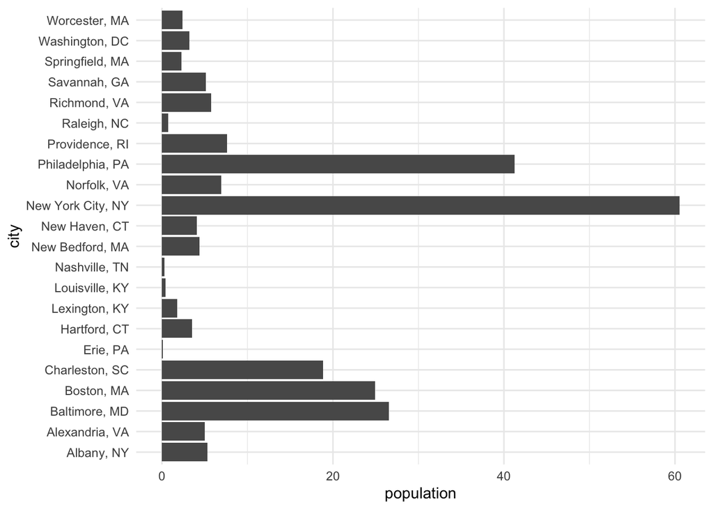

```r
us |>
  filter(year == 1800) |>
  filter(population > 0) |>
  arrange(population) |>
  ggplot(aes(population, city)) +
  geom_col()
```

Copy the code from above but wrap the variable `city` in the function `fct_inorder` when setting it to the y aesthetic.

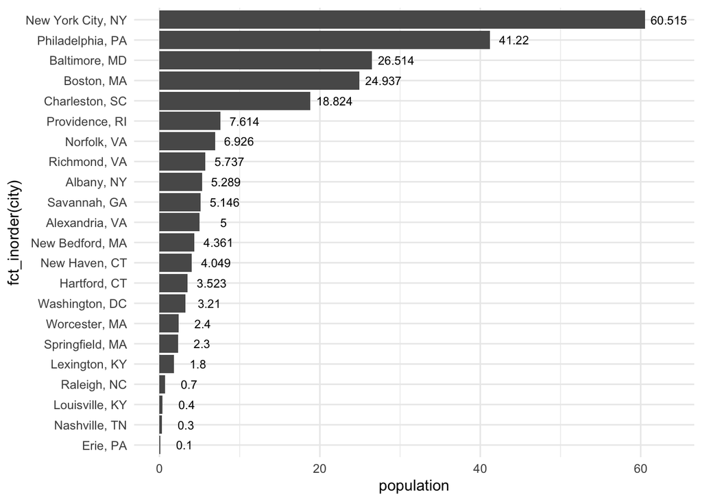

```r
us |>
  filter(year == 1800) |>
  filter(population > 0) |>
  arrange(population) |>
  ggplot(aes(population, fct_inorder(city))) +
  geom_col() +
  geom_text(aes(population + 3, fct_inorder(city), label = population), size = 3)
```

You should now notice that the cities are arranged by population. We will talk more about this function in future notes.